# SF Bike Trips Analysis

Zihao Zhang  
Data Science, Analytic Partners  
zihao.zhang@analyticpartners.com

July 31, 2017

# Content

The slides showing the whole process on machine learning project on a public data set San Francisco Bike Usage data set (https://www.kaggle.com/benhamner/sf-bay-area-bike-share)

- Data Processing and Exploring
- Feaure Engineering
- Modeling, parameter tuning
- Model comparison

# Total Market Trend across Time

There appears to be an intersting split in the data. There is a vairable, perhaps it has to do with Day of Week.

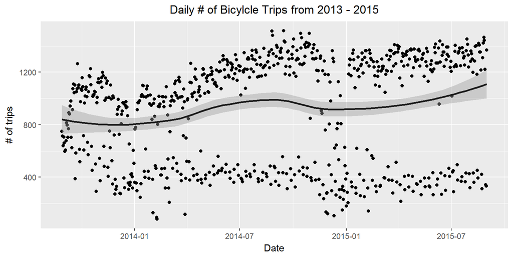

# Different Patterns between Weekday and Weekend

It’s always important to visualize the results first. The following plot shows that there are different patterns for weekday and weekends.

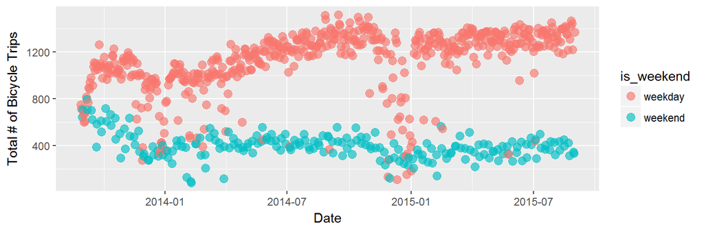

# Bicycle Trip Heatmap during Daytime

Around 8-9AM and 5-6PM at weekdays colored most. My guess is that most part of bicycle users are locals, they use bicycle for their daily commute between office and home.

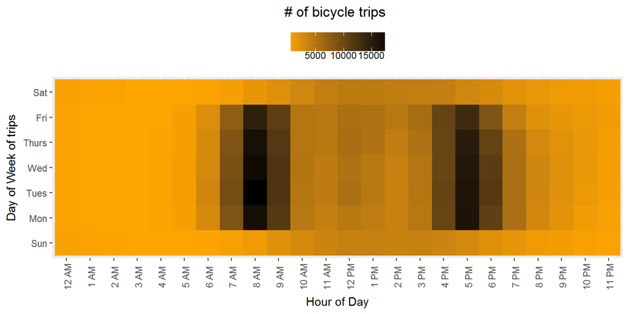

# Factor by User Type

Subscribers dominate bicycle usage on the weekday. At weekend, the usage is more balanced.

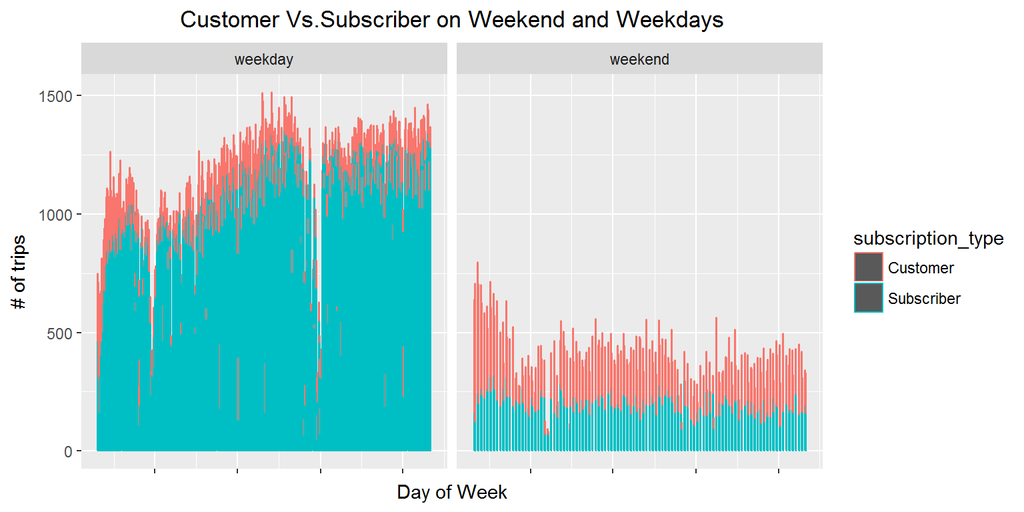

# Bicycle Trips Distribution at Different Cities

- San Francisco has the larget Bike Share demanded.
- Followed by San Jose.
- Bike Share program is spread in Bay Area.

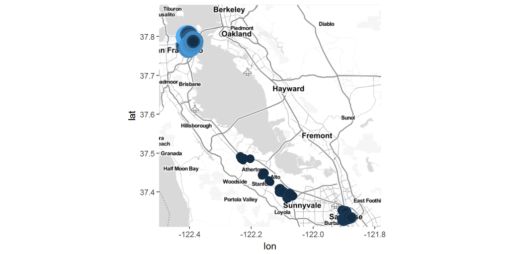

# Features Engineering

Feature engineering is important. Usually in a machine learning project, more than 50% time are spent in data exploring and feature engeering

- Find all of the **holidays** during our time span
- Convert dates to **season**
- one-hot-encoding for categorical variables

# Modeling Process

Outcome is the number of trips taken, at a given hour per day, with bike sharing program.

Input features: type of day, subscription_type, city and weather report (temperature, wind speed, humidity, etc.)

Models I used are two popular tree-based machine learning models, they are famous for the high prediction accuracy:

- Random Forest
- Gradient Boosting

# Random Forest

- Tuning parameters: number of trees, number of predictors considered at each split.
- Use 10 fold cross validation to tune parameters and RMSE on the test dataset as validation metrics
- Random Forest randomly generate multiple trees and average the all trees eventually. So there are some variation along the direction to better model (this is different from XGboost that you will see soon)

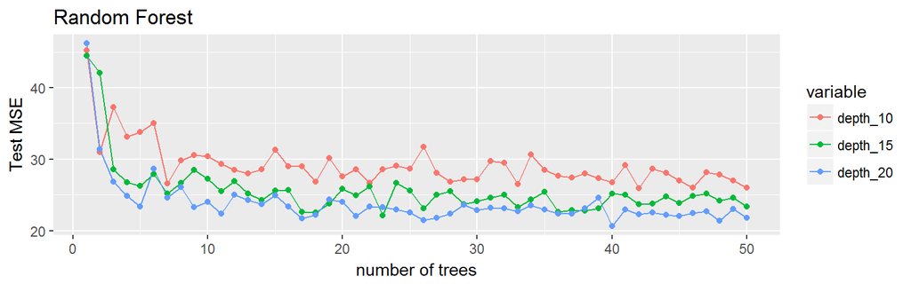

# Gradient Boosting

- Tuning parameters: number of trees, depth of the treee, learning rate.
- Use 10 fold cross validation to tune parameters and RMSE on the test dataset as validation metrics.
- XGboost leverage Gradient Descent method, so we will see the RMSE keep decreasing with more steps. But we need to carefully tune the learning rate parameter to avoid overfitting.

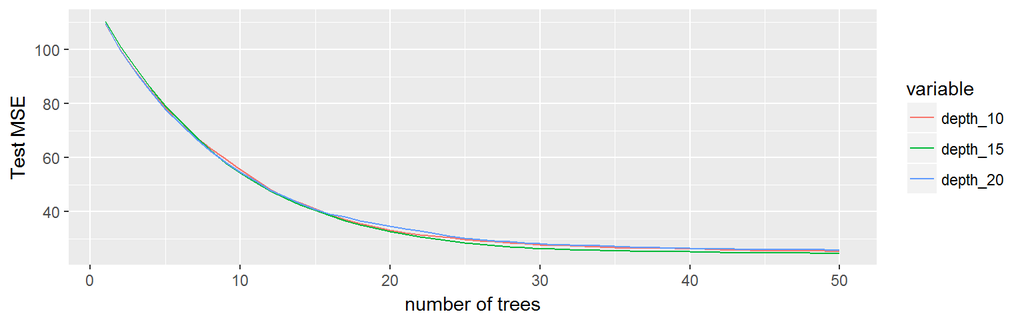

# Model Comparison: Variable Importance

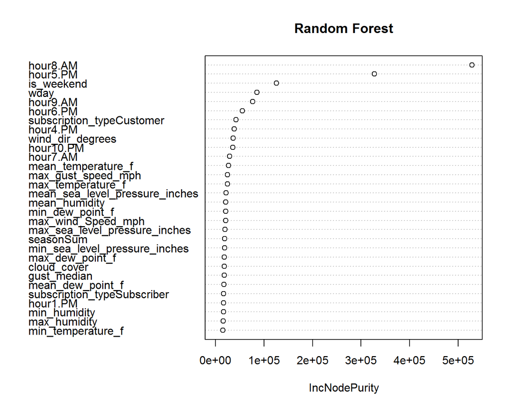

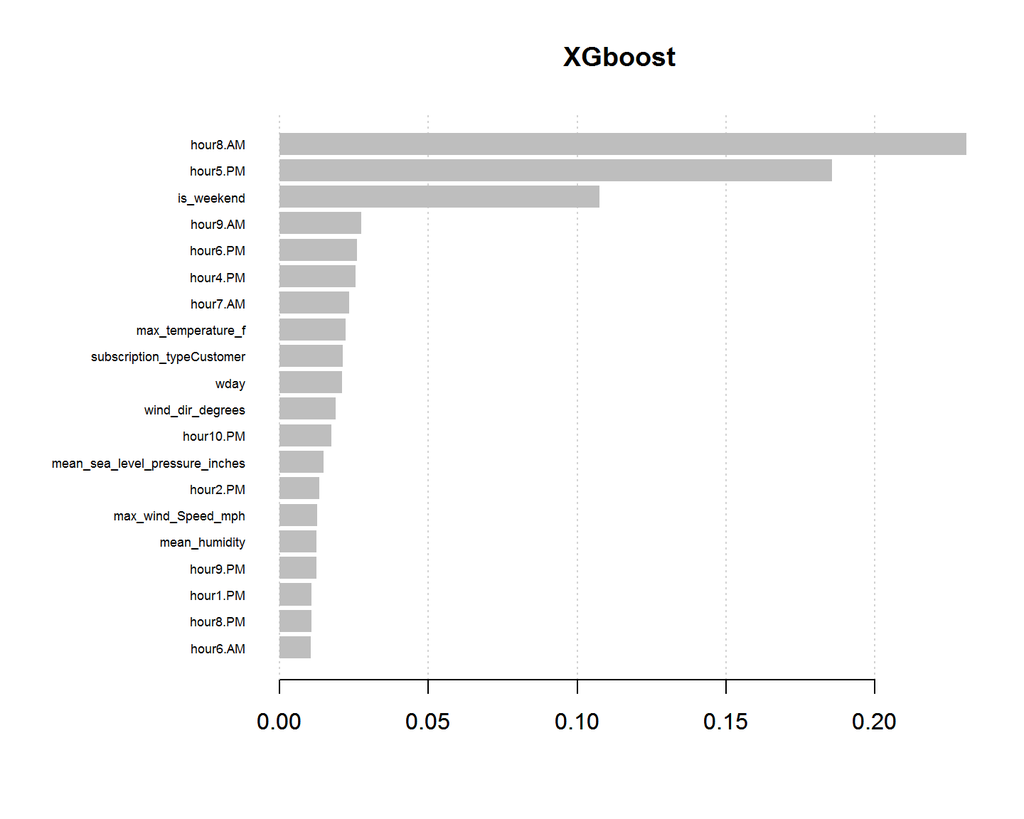

# Model Comparison: Predicted Value

Both Random Forest and XGboost have pretty good estimation in new test dataset.

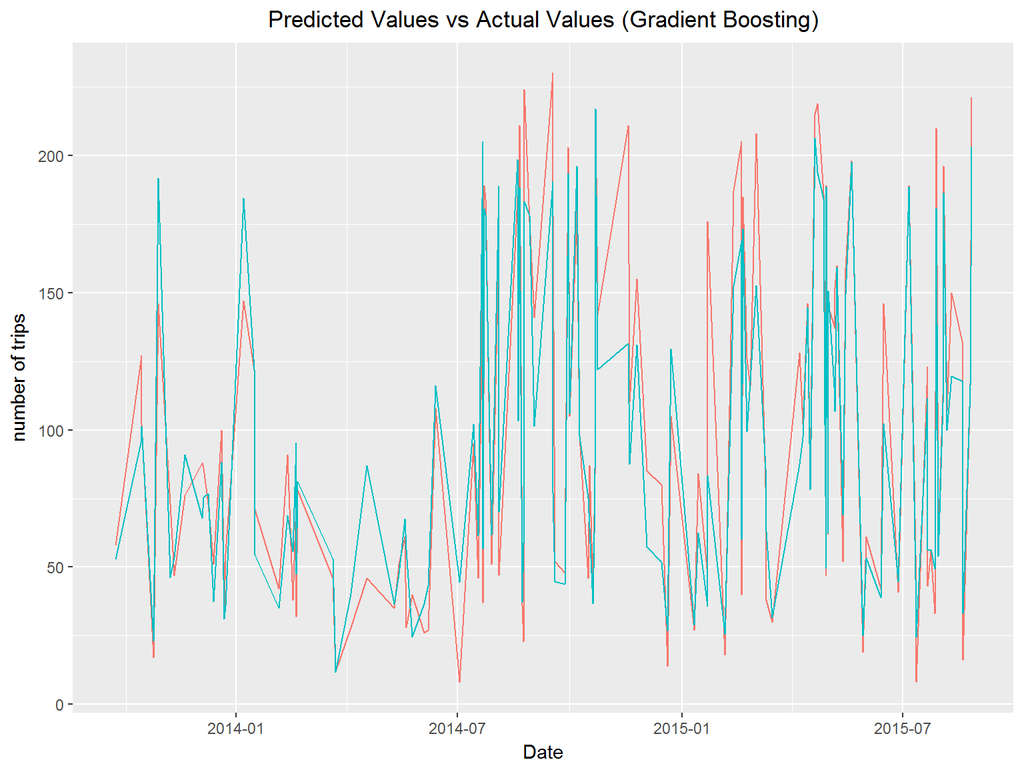

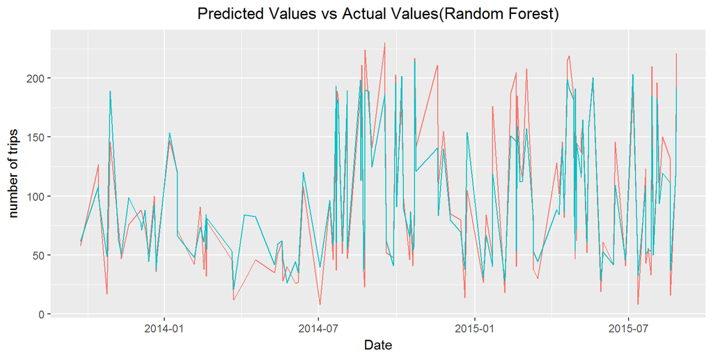

# Summary

- Both models are aimed to predict how many trips will occur in the San Francisco Bay Area with bike sharing service.
- The bike usage is more affected by the day type - use more on weekdays, and less affected by the weather.
- SF has a larger service than other cites in Bay Area.
- Customers have similar usage patterns in different cities.